```python
import numba                       # JIT-Kompilierung zur Beschleunigung numerischer Funktionen
import numpy as np                 # Numerische Berechnungen und Array-Verarbeitung
import matplotlib.pyplot as plt    # Plotten und Visualisieren von Daten (z. B. Mandelbrot-Menge)
import matplotlib.ticker as ticker # Für die Feinjustierung der yticks bei den ersten beiden Balkendiagrammen
import scipy.linalg as linalg      # Lineare Algebra-Operationen (z. B. Matrixzerlegung)
import time                        # Zugriff auf Zeitfunktionen wie sleep oder time()
import timeit                      # Modul für präzise Zeitmessung und Performance-Benchmarking
import threading, subprocess, os   # Für den CPU-Auslastungsmonitor (Parallelitätsprüfung unter Linux)
                                   # Funktioniert nur unter Linux: Überwacht die CPU-Auslastung während der Berechnung
                                   # Zeigt, ob numba mit `target='parallel'` tatsächlich mehrere Kerne nutzt
from matplotlib.animation import FuncAnimation#, PillowWriter  # Für Animationserstellung und -export (z. B. als GIF)
from matplotlib.patches import Circle # Für das Zeichnen von Kreisen in Plots
from time import perf_counter_ns   # Hochauflösende Zeitmessung in Nanosekunden
from numba import njit, prange     # Spezielle Numba-Funktionen: @njit für JIT, prange für parallele Schleifen
from numba import vectorize, int32, int64, complex128 # Wird benötigt für die Dekoratoren
from IPython.display import HTML   # Anzeige von HTML-Inhalten in Jupyter-Notebooks
```

# Einsendeaufgabe 3: Numba (100 Punkte)

In diesem Abschnitt möchten wir unsere Applikationen mit Numba beschleunigen.

## Mandelbrot-Set (10 Punkte)

Wir beginnen mit einem klassischen Beispiel für Parallelisierung: dem Mandelbrot-Set.

Die Mandelbrot-Menge wird durch die Gleichung $z_{n+1} = z_n^2 + c$ beschrieben. In dieser Gleichung sind $c$ und $z$ komplexe Zahlen, und $n$ ist Null oder eine positive ganze Zahl. Ausgehend von $z_0=0$, gehört $c$ zur Mandelbrot-Menge, wenn der Absolutwert von $z_n$ niemals größer als eine bestimmte Zahl wird (diese Zahl ist abhängig von $c$), egal wie groß $n$ wird.

Das bedeutet, eine komplexe Zahl $c$ ist ein Element der Mandelbrotmenge, wenn die Beträge der mit diesem $c$ berechneten $z_{n}$ nicht unbegrenzt wachsen, unabhängig davon, wie groß $n$ wird. Es lässt sich leicht zeigen, dass der Betrag von $z_{n}$ unbegrenzt wächst, sobald ein $z_{n}$ mit $|z_{n}|>2$ auftritt.

Bei der Berechnung des Mandelbrot-Sets legt man oft eine obere Grenze für die maximalen Iterationen fest, um zu testen, ob diese überschritten wird.

Ein einfacher Algorithmus zur Bestimmung, ob ein Wert zum Mandelbrot-Set gehört, sieht folgendermaßen aus:

```python
import numba
import numpy as np
from numpy import vectorize


def escape_time(p, maxiter):
    """Perform the Mandelbrot iteration until it's clear that p diverges
    or the maximum number of iterations has been reached.

    Parameters
    ----------
    p: complex
        point in the complex plane
    maxiter: int
        maximum number of iterations to perform before p is considered in
        the Mandelbrot set.
    """
    z = 0j
    for i in range(maxiter):
        z = z**2 + p
        if abs(z) > 2:
            return i
    return maxiter


a = np.array([0.2 + 0.2j])
escape_time(a, 400)
```

```
400
```

Die Zahl $0.2+0.2j$ liegt also in der Mandelbrot Menge, da wir nach 400 Iterationen noch nicht die Abbruchbedingung erfüllen. Allerdings ist es mühsam, jede Zahl einzeln zu testen. Wir erstellen also ein 2-D Feld mit vielen Komplexen Zahlen $|z|<2$:

```python
real_param = (-1.5, 1.1, 1500) # Tupel mit drei Werten: (Start, Stop, Anzahl Schritte) für den realen Teil der komplexen Zahl
imag_param = (-1.5j, 1.1j, 1500) # Tupel mit drei Werten: (Start, Stop, Anzahl Schritte) für den imaginären Teil der komplexen Zahl

# Von -1.5 bis 1.1, in 1500 Schritten (für die x-Achse bzw. den Realteil der komplexen Zahlen)
# Von -1.5j bis 1.1j, auch in 1500 Schritten (für die y-Achse bzw. den Imaginärteil)
# z. B. p.linspace(*(-1.5, 1.1, 1500)) wird zu np.linspace(-1.5, 1.1, 1500).
# Der Stern ist ist ein "Unpacking Operator" in Python.
XX, YY = np.meshgrid(np.linspace(*real_param), np.linspace(*imag_param))

# Erzeugt ein 2D-Feld komplexer Zahlen aus den Gitterpunkten:
# XX enthält die Realteile, YY die Imaginärteile → ergibt die komplexen Zahlen c = x + iy
P = XX + YY
```

**Aufgabe:**

- Vektorisieren Sie die Funktion mit `np.vectorize`
- Vektorisieren Sie die Funktion mit `numba.vectorize`
- Testen Sie, ob der Parallel-Parameter funktioniert und ob er Performance-Vorteile bringt
- Vergleichen Sie die Laufzeit der drei Versionen und stellen Sie den Vergleich graphisch dar

*Points:* 7

## Vektorisierung mit `np.vectorize` und `numba.vectorize` – inklusive Performance-Vergleich

In dieser Aufgabe berechnen wir die Mandelbrot-Menge mithilfe des *Escape-Time-Verfahrens*. Dabei wird für jeden Punkt der komplexen Ebene iterativ überprüft, ob die Folge $z_{n+1} = z_n^2 + p$ den Betrag 2 überschreitet. Die Anzahl der benötigten Iterationen bis zum Überschreiten (oder Erreichen des Maximums) nennt man *Escape-Time*.

Das Verfahren ist rechenintensiv. Daher ist es ideal, um verschiedene Optimierungsansätze durch **Vektorisierung** zu vergleichen. Vektorisierung bedeutet hier: Wir formulieren die Escape-Time-Funktion so, dass sie auf ganze Arrays gleichzeitig angewendet werden kann, was die Rechenleistung erheblich steigern kann.

Wir untersuchen drei Varianten:

1. **`np.vectorize`** – einfache Anwendung auf Arrays, aber ohne echte Performance-Vorteile (nur syntaktischer Zucker).
2. **`numba.vectorize`** – Just-in-Time-Kompilierung zu Maschinencode für echte Geschwindigkeitsgewinne.
3. **`numba.vectorize(..., target='parallel')`** – zusätzlich mit Multi-Core-Parallelausführung.

Wir messen und vergleichen die Ausführungszeiten mit `timeit`, um zu zeigen, wie sich die Wahl der Methode auf die Rechenzeit auswirkt.

```
Zeit für np.vectorize:                7.8465 Sekunden
Zeit für numba.vectorize:            0.1835 Sekunden
Zeit für numba.vectorize (parallel): 0.0543 Sekunden
Zeit für numba njit + prange:        0.0514 Sekunden
```

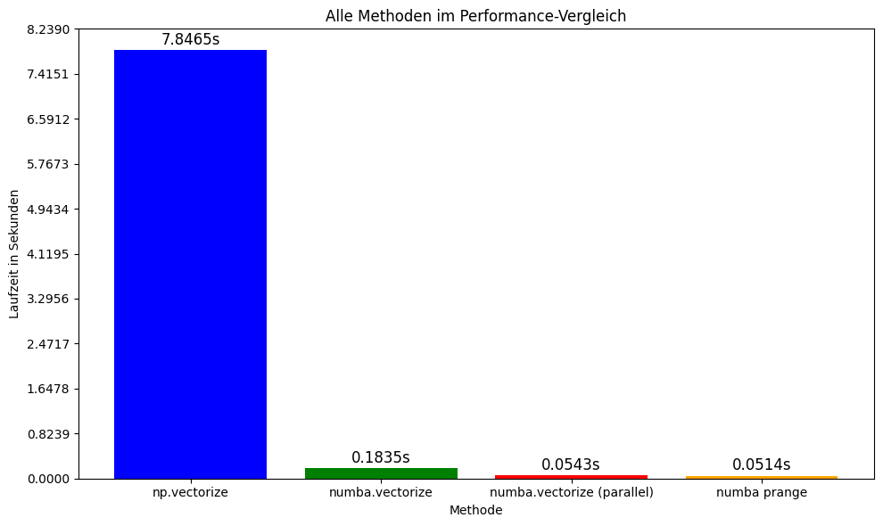

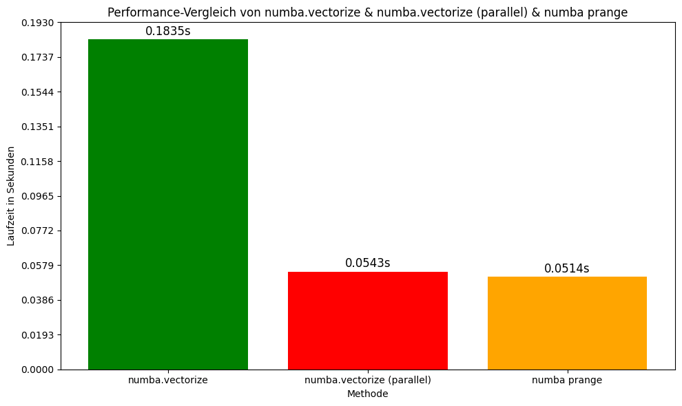

```python
# -------------------------------------------------------------------
# Funktion zum Plotten der Laufzeiten
def plot_laufzeiten(laufzeiten, fokus='alle'):  # Funktion zur Darstellung von Laufzeiten
    # Methoden & zugehörige Farben definieren
    methoden = ['np.vectorize', 'numba.vectorize', 'numba.vectorize (parallel)', 'numba prange'] # Namen der Methoden
    farben = ['blue', 'green', 'red', 'orange'] # Farben für die Balken

    # Auswahl je nach Fokus (alle oder nur numba)
    if fokus == 'alle':  # Wenn alle Methoden gezeigt werden sollen
        m, lz, titel = methoden, laufzeiten, 'Alle Methoden im Performance-Vergleich'  # Alle Werte verwenden
    elif fokus == 'numba':  # Wenn nur numba-Varianten verglichen werden sollen
        m, lz, farben = methoden[1:], laufzeiten[1:], farben[1:]  # Nur numba-Werte/Farben
        titel = 'Performance-Vergleich von numba.vectorize & numba.vectorize (parallel) & numba prange'  # Titel anpassen

    # Diagramm vorbereiten
    plt.figure(figsize=(10, 6))  # Neue Plotfläche mit Größe 10x6
    plt.bar(m, lz, color=farben)  # Balkendiagramm zeichnen
    plt.xlabel('Methode')  # X-Achsenbeschriftung
    plt.ylabel('Laufzeit in Sekunden')  # Y-Achsenbeschriftung
    plt.title(titel)  # Diagrammtitel setzen

    # Achsengrenzen und Puffer
    ymin = 0  # Untere Y-Grenze (immer bei 0 starten)
    ymax = max(lz)  # Höchster Laufzeitwert
    bereich = ymax - ymin  # Differenz als Basis für Puffer
    puffer = bereich * 0.05  # 5 % Puffer oberhalb des höchsten Balkens
    start = ymin  # Start bei 0
    stop = ymax + puffer  # Obergrenze mit Puffer
    plt.ylim(start, stop)  # Y-Achse festlegen

    # y-Achsen-Ticks und Format (vier Nachkommastellen)
    tick_step = round((stop - start) / 10, 4)  # Schrittgröße für Ticks (10 gleichmäßige Schritte)
    plt.yticks(np.arange(start, stop + tick_step, tick_step))  # Y-Ticks setzen
    plt.gca().yaxis.set_major_formatter(ticker.FormatStrFormatter('%.4f'))  # Y-Achsenwerte auf 4 Nachkommastellen formatieren

    # Balkenbeschriftungen einfügen
    for i, v in enumerate(lz):  # Schleife über Balken
        x_position = i  # X-Position des Balkens
        y_position = v + puffer * 0.1  # Y-Position leicht über dem Balken
        text = f'{v:.4f}s'  # Textformat mit 4 Nachkommastellen + 's'

        plt.text(  # Text ins Diagramm einfügen
            x_position,      # X-Position des Textes
            y_position,      # Y-Position des Textes
            text,            # Der anzuzeigende Text
            ha='center',     # Horizontal zentriert
            va='bottom',     # Vertikal, "unterer Rand des Textes" auf y_position
            fontsize=12      # Schriftgröße
        )

    # Layout optimieren und anzeigen
    plt.tight_layout()  # Layout automatisch anpassen
    plt.show()  # Diagramm anzeigen

# -------------------------------------------------------------------
# ESCAPE-TIME-FUNKTION (Basisversion für np.vectorize)
def escape_time(p, maxiter):
    z = 0j
    for i in range(maxiter):
        z = z * z + p
        if z.real * z.real + z.imag * z.imag > 4.0:
            return i
    return maxiter

# -------------------------------------------------------------------
# VARIANTE 1: np.vectorize (kein echter Speedup, aber bequeme API)
mandelbrot_set_np_vectorized = np.vectorize(escape_time)

def run_np(P, maxiter):
    return mandelbrot_set_np_vectorized(P, maxiter)

# -------------------------------------------------------------------
# Signaturen für numba.vectorize
signatures = [
    int32(complex128, int32),
    int32(complex128, int64),
]

# -------------------------------------------------------------------
# VARIANTE 2: numba.vectorize (JIT-kompiliert, schneller)
@vectorize(signatures)
def escape_time_numba(p, maxiter):
    z = 0j
    for i in range(maxiter):
        z = z * z + p
        if z.real * z.real + z.imag * z.imag > 4.0:
            return i
    return maxiter

def run_numba(P, maxiter):
    return escape_time_numba(P, maxiter)

# -------------------------------------------------------------------
# VARIANTE 3: numba.vectorize mit Parallelisierung (target='parallel')
@vectorize(signatures, target='parallel')
def escape_time_numba_par(p, maxiter):
    z = 0j
    for i in range(maxiter):
        z = z * z + p
        if z.real * z.real + z.imag * z.imag > 4.0:
            return i
    return maxiter

def run_numba_par(P, maxiter):
    return escape_time_numba_par(P, maxiter)

# -------------------------------------------------------------------
# VARIANTE 4: numba njit + prange (explizite Parallel-Schleife)
@njit(parallel=True)
def escape_time_numba_prange(P, maxiter):
    M, N = P.shape
    result = np.empty((M, N), dtype=np.int32)
    for i in prange(M):
        for j in range(N):
            z = 0j
            c = P[i, j]
            for k in range(maxiter):
                z = z * z + c
                if z.real * z.real + z.imag * z.imag > 4.0:
                    result[i, j] = k
                    break
            else:
                result[i, j] = maxiter
    return result

def run_numba_prange(P, maxiter):
    return escape_time_numba_prange(P, maxiter)

# -------------------------------------------------------------------
# Hilfsfunktion zur Zeitmessung (ohne Profiling)
def timed_run(func, *args):
    start = timeit.default_timer()
    result = func(*args)
    end = timeit.default_timer()
    return result, round(end - start, 4)

# -------------------------------------------------------------------
# Grid der komplexen Zahlen
real_param = (-1.5, 1.1, 1000)
imag_param = (-1.5, 1.1, 1000)
XX, YY = np.meshgrid(np.linspace(*real_param), np.linspace(*imag_param))
P = XX + 1j * YY

maxiter = 200

# -------------------------------------------------------------------
# Vorwärmen (JIT-Kompilierung triggern)
_ = run_numba(P, maxiter)
_ = run_numba_par(P, maxiter)
_ = run_numba_prange(P, maxiter)

# -------------------------------------------------------------------
# Zeitmessung
_, time_np = timed_run(run_np, P, maxiter)
_, time_numba = timed_run(run_numba, P, maxiter)
_, time_numba_par = timed_run(run_numba_par, P, maxiter)
_, time_numba_prange = timed_run(run_numba_prange, P, maxiter)

print(f"Zeit für np.vectorize:                {time_np:.4f} Sekunden")
print(f"Zeit für numba.vectorize:            {time_numba:.4f} Sekunden")
print(f"Zeit für numba.vectorize (parallel): {time_numba_par:.4f} Sekunden")
print(f"Zeit für numba njit + prange:        {time_numba_prange:.4f} Sekunden")

# Aufrufe der Funktion für beide Varianten
# Aufruf mit aktuellen Zeiten:
laufzeiten = [time_np, time_numba, time_numba_par, time_numba_prange]
plot_laufzeiten(laufzeiten) # Zeigt alle drei Methoden
plot_laufzeiten(laufzeiten, fokus='numba') # Zeigt nur numba-Methoden
```

Mit *plt.imshow(M)* können Sie sich die Mandelbrotmenge $M$ ansehen:

[figure not shown]

```python
M = mandelbrot_set_numba_vectorized_par(P, maxiter)
plt.imshow(M, extent=[real_param[0], real_param[1], imag_param[0].imag, imag_param[1].imag], origin='lower')
plt.gca().set_aspect('equal', adjustable='box')
plt.xlim(real_param[0], real_param[1]-0.5)
plt.ylim(imag_param[0].imag+0.5, imag_param[1].imag )
plt.title("Mandelbrot-Menge", fontsize=14)
plt.xlabel("Re")
plt.ylabel("Im")
plt.colorbar(label="Iterationsanzahl")
plt.show()
```

**Aufgabe:** Vergleichen Sie nun die drei Versionen mit Scalene. Verwenden sie eine Sampling-Rate von $0.0001$

*Points:* 3

```python
%load_ext scalene
```

```
Scalene extension successfully loaded. Note: Scalene currently only
supports CPU+GPU profiling inside Jupyter notebooks. For full Scalene
profiling, use the command line version. To profile in line mode, use
`%scrun [options] statement`. To profile in cell mode, use `%%scalene
[options]` followed by your code.
```

```python
%%scalene --cpu-only --sample-rate 0.0001
# Diese Methode verwendet keine parallelen Threads
_, t = timed_run(run_np, P, maxiter)
print(f"Zeit für np.vectorize (single-threaded): {t:.4f} Sekunden")
```

```
Zeit für np.vectorize (single-threaded): 8.6021 Sekunden
                   /home/jovyan/materials/_ipython-input-52-profile: % of time = 100.00% (8.603s) out of 8.603s.
        ╷        ╷       ╷       ╷
        │Time    │–––––– │–––––– │
  Line  │Python  │native │system │/home/jovyan/materials/_ipython-input-52-profile
╺━━━━━━━┿━━━━━━━━┿━━━━━━━┿━━━━━━━┿━━━━━━━━━━━━━━━━━━━━━━━━━━━━━━━━━━━━━━━━━━━━━━━━━━━━━━━━━━━━━━━━━━━━━━━━━━━━━━━━━━━━━━━━━━━━━━━━╸
      1 │        │       │       │
      2 │        │       │       │# Diese Methode verwendet keine parallelen Threads
      3 │   92%  │    8% │       │_, t = timed_run(run_np, P, maxiter)
      4 │        │       │       │print(f"Zeit für np.vectorize (single-threaded): {t:.4f} Sekunden")
      5 │        │       │       │
        ╵        ╵       ╵       ╵
```

```python
%%scalene --cpu-only --sample-rate 0.0001
# Diese Numba-Methode nutzt keine explizite Parallelisierung
_, t = timed_run(run_numba, P, maxiter)
print(f"Zeit für numba.vectorize (single-threaded): {t:.4f} Sekunden")
```

```
Zeit für numba.vectorize (single-threaded): 0.3208 Sekunden
                /home/jovyan/materials/_ipython-input-53-profile: % of time = 100.00% (322.004ms) out of 322.004ms.
        ╷        ╷       ╷       ╷
        │Time    │–––––– │–––––– │
  Line  │Python  │native │system │/home/jovyan/materials/_ipython-input-53-profile
╺━━━━━━━┿━━━━━━━━┿━━━━━━━┿━━━━━━━┿━━━━━━━━━━━━━━━━━━━━━━━━━━━━━━━━━━━━━━━━━━━━━━━━━━━━━━━━━━━━━━━━━━━━━━━━━━━━━━━━━━━━━━━━━━━━━━━━╸
      1 │        │       │       │
      2 │        │       │       │# Diese Numba-Methode nutzt keine explizite Parallelisierung
      3 │        │    6% │  94%  │_, t = timed_run(run_numba, P, maxiter)
      4 │        │       │       │print(f"Zeit für numba.vectorize (single-threaded): {t:.4f} Sekunden")
      5 │        │       │       │
        ╵        ╵       ╵       ╵
```

```python
%%scalene --cpu-only --sample-rate 0.0001
# Diese Methode nutzt parallele Threads – Scalene misst Thread-Zeit separat!
_, t = timed_run(run_numba_par, P, maxiter)
print(f"Zeit für numba.vectorize (parallel): {t:.4f} Sekunden")
```

```
Zeit für numba.vectorize (parallel): 0.2019 Sekunden
                /home/jovyan/materials/_ipython-input-54-profile: % of time = 100.00% (203.537ms) out of 203.537ms.
        ╷        ╷       ╷       ╷
        │Time    │–––––– │–––––– │
  Line  │Python  │native │system │/home/jovyan/materials/_ipython-input-54-profile
╺━━━━━━━┿━━━━━━━━┿━━━━━━━┿━━━━━━━┿━━━━━━━━━━━━━━━━━━━━━━━━━━━━━━━━━━━━━━━━━━━━━━━━━━━━━━━━━━━━━━━━━━━━━━━━━━━━━━━━━━━━━━━━━━━━━━━━╸
      1 │        │       │       │
      2 │        │       │       │# Diese Methode nutzt parallele Threads – Scalene misst Thread-Zeit separat!
      3 │        │   16% │  84%  │_, t = timed_run(run_numba_par, P, maxiter)
      4 │        │       │       │print(f"Zeit für numba.vectorize (parallel): {t:.4f} Sekunden")
      5 │        │       │       │
        ╵        ╵       ╵       ╵
```

```python
%%scalene --cpu-only --sample-rate 0.0001
# Diese Variante nutzt prange (multithreaded Schleifen) – Thread-Zeit beachten!
_, t = timed_run(run_numba_prange, P, maxiter)
print(f"Zeit für numba njit + prange: {t:.4f} Sekunden")
```

```
Zeit für numba njit + prange: 0.1910 Sekunden
                /home/jovyan/materials/_ipython-input-55-profile: % of time = 100.00% (192.376ms) out of 192.376ms.
        ╷        ╷       ╷       ╷
        │Time    │–––––– │–––––– │
  Line  │Python  │native │system │/home/jovyan/materials/_ipython-input-55-profile
╺━━━━━━━┿━━━━━━━━┿━━━━━━━┿━━━━━━━┿━━━━━━━━━━━━━━━━━━━━━━━━━━━━━━━━━━━━━━━━━━━━━━━━━━━━━━━━━━━━━━━━━━━━━━━━━━━━━━━━━━━━━━━━━━━━━━━━╸
      1 │        │       │       │
      2 │        │       │       │# Diese Variante nutzt prange (multithreaded Schleifen) – Thread-Zeit beachten!
      3 │        │   13% │  86%  │_, t = timed_run(run_numba_prange, P, maxiter)
      4 │        │       │       │print(f"Zeit für numba njit + prange: {t:.4f} Sekunden")
      5 │        │       │       │
        ╵        ╵       ╵       ╵
```

### Warum `%%scalene --cpu-only --sample-rate 0.0001`?

- `--cpu-only`: Wir wollen CPU-Profiling, da die Funktionen CPU-lastig sind und kein GPU verwendet wird.
- `--sample-rate 0.0001`: Genau wie in der Aufgabe vorgegeben, um hohe Sampling-Genauigkeit zu gewährleisten.

### Scalene-Ausgabe

- **Time Python**:
  - Zeit im Python-Interpreter
- **Native**:
  - Zeit in nativem C oder C++
- **System**:
  - kompilierter Numba-Code, NumPy C-Funktionen, OS-Calls, Threads

### Fazit

Die Scalene-Profilierung zeigt bei den numba-basierten Varianten erwartungsgemäß nahezu 0 % Python-Zeit und sehr hohe System-Zeitanteile. Dies belegt, dass der Code größtenteils außerhalb des Python-Interpreters ausgeführt wird, nämlich als kompilierter Maschinencode, erzeugt durch numba.

Die geringe „Native“-Zeit erklärt sich dadurch, dass keine externen C/C++-Bibliotheken über Schnittstellen eingebunden wurden, alles läuft innerhalb der vom numba erzeugten LLVM-Optimierungen (Low Level Virtual Machine).

Dies bestätigt die hohe Effizienz der numba-Lösungen und den erfolgreichen Einsatz von JIT-Kompilierung zur Performance-Steigerung.

## Springende Bälle, Teil 2 (60 Punkte)

Wir wollen die Simulation mit mehreren Bällen verbessern und optimieren.

Jetzt werden zusätzlich Kollisionen zwischen den Bällen beachtet. Dafür wollen wir zunächst berechnen, ob die Bälle in einem Zeitschritt kollidieren. Eine genaue Berechnung ist hier sehr schwer, daher können wir dies nur näherungsweise machen. Wir müssen dazu auch folgende Annahmen machen:

1. Die Bälle haben einen Radius von $r$, alle Bälle sind gleich groß
2. Der Zeitschritt $\Delta t$ und die Geschwindigkeit $\$v$ der Bälle sind so gewählt, dass ein Ball maximal viermal seinen Radius in einem Zeitschritt zurücklegt, also $v*\Delta t <= 4*r$

Wir berechnen nun in jeden Zeitschritt zunächst 3 zusätzliche Zwischenzeitschritte:

$ c_0 = c_0$

$c_1 = c_0+0.25\Delta t *v$

$c_3 = c_0+0.5\Delta t *v$

$c_4 = c_0+0.75\Delta t * v$

(Der nächste Schritt wäre $\Delta t$, dieser wird aber in der nächsten Iteration beachtet.)

Wir betrachten nun jeweils für 2 Bälle, ob sie sich in einem der Zwischenzeitschritte näher als zweimal dem Radius $r$ kommen. Wenn sie das tun, gibt es eine Kollision.

**Aufgabe:** Schreiben Sie eine Funktion, die dies für zwei Bälle testet und zunächst `True` oder `False` zurück gibt. Für die Berechnung des Abstands können sie die Funktion `np.linalg.norm` verwenden.

*Points:* 10

```python
def will_collide(c1, c2, v1, v2, r1, r2, dt):
    """
    Prüft, ob zwei Bälle sich innerhalb eines Zeitschritts dt kollidieren werden.
    Eingabeparameter sind erweitert, um Bälle mit und Radien zu berücksichtigen.

    Parameter:
    - c1, c2:   Positionen von Ball 1 und 2
    - v1, v2:   Geschwindigkeiten von Ball 1 und 2
    - r1, r2:   Radien von Ball 1 und 2
    - dt:       Zeitschritt

    Rückgabewerte:
    - collided:                 Status: Ob eine Kollision erkannt wurde
    - k_frac:                   Fraktion des Zeitschritts, bei dem die Kollision stattfindet
    - c1_before, c2_before:     Positionen von Ball 1 und 2 vor der Kollision
    """

    # Vorinitialisierung
    collided = False
    k_frac = 0
    c1_before = c1
    c2_before = c2
    k_values = [0, 0.25, 0.5, 0.75]  # Zeitanteile innerhalb des Zeitschritts

    for k in k_values:
        # Positionen der Bälle nach k * dt
        c1_pos = c1 + k * dt * v1
        c2_pos = c2 + k * dt * v2

        # Berechnung des Abstands zwischen den Bällen nach jedem k
        distance = np.linalg.norm(c1_pos - c2_pos)

        # Wenn Abstand kleiner als die Summe der Radien beider Bälle ist -> Kollision
        if distance < (r1 + r2):
            # Aktualisierung der Werte
            collided = True
            k_frac = k
            c1_before = c1_pos
            c2_before = c2_pos
            break  # Kollision gefunden -> Abbruch der Schleife

    return collided, k_frac, c1_before, c2_before
```

Um die Geschwindigkeiten der Bälle nach einer Kollision zu berechnen, können wir die Erhaltung des Impulses und die Erhaltung der kinetischen Energie heranziehen, unter der Annahme, dass es sich um eine vollkommen elastische Kollision handelt. Bei einer solchen Kollision bleiben sowohl der Gesamtimpuls als auch die gesamte kinetische Energie des Systems erhalten. Die Berechnungen werden allerdings etwas komplexer, wenn wir Richtungen berücksichtigen.

#### Geschwindigkeiten nach der Kollision

Für zwei Bälle mit Massen $m_1$ und $m_2$, den Anfangsgeschwindigkeiten $v_1$ und $v_2$ und den Endgeschwindigkeiten $v_1'$ und $v_2'$ gelten folgende Gleichungen basierend auf dem Impulserhaltungssatz und der Erhaltung der kinetischen Energie:

1. **Impulserhaltung:** $m_1 v_1 + m_2 v_2 = m_1 v_1' + m_2 v_2'$
2. **Erhaltung der kinetischen Energie:** $\frac{1}{2} m_1 v_1^2 + \frac{1}{2} m_2 v_2^2 = \frac{1}{2} m_1 {v_1'}^2 + \frac{1}{2} m_2 {v_2'}^2$

Diese Gleichungen müssen vektoriell gelöst werden, da die Geschwindigkeiten Richtungen haben.

Die Lösungen für die Geschwindigkeiten nach der Kollision in zwei Dimensionen unter der Annahme einer vollkommen elastischen Kollision und unter Ignorierung der Rotation der Bälle sind:

$v_1' = v_1 - \frac{2 m_2}{m_1 + m_2} \frac{(v_1 - v_2) \cdot (c_1 - c_2)}{\|c_1 - c_2\|^2} (c_1 - c_2)$

$v_2' = v_2 + \frac{2 m_1}{m_1 + m_2} \frac{(v_1 - v_2) \cdot (c_1 - c_2)}{\|c_1 - c_2\|^2} (c_1 - c_2)$

Hierbei ist $(v_1 - v_2) \cdot (c_1 - c_2)$ das Skalarprodukt der Vektoren $v_1 - v_2$ und $c_1 - c_2$, und $\|c_1 - c_2\|$ ist der Betrag des Vektors $(c_1 - c_2)$, welcher den Abstand zwischen den Zentren der Bälle darstellt.

**Aufgabe:** Schreiben Sie eine Funktion, welche die neuen Geschwindigkeiten der Bälle NACH einer Kollision berechnet.  
Sie übergeben der Funktion die folgenden Daten.

- Koordinaten ($c_1, c_2$)
- Geschwindigkeiten ($v_1, v_2$)
- Massen ($m_1, m_2$)

Für die Berechnung des Betrags können Sie wiederum die Funktion `np.linalg.norm` verwenden.

*Points:* 10

```python
def collision(c1, c2, v1, v2, m1, m2):
    """
    Berechnet die elastische Kollision zwischen den Bällen 1 und 2

    Parameter:
    - c1, c2:   Positionen von Ball 1 und 2
    - v1, v2:   Geschwindigkeiten von Ball 1 und 2
    - r1, r2:   Radien von Ball 1 und 2
    - m1, m2:   Massen von Ball 1 und 2

    Rückgabewerte:
    - v1_new, v2_new:   Neue Geschwindigkeiten von Ball 1 und 2 nach Kollision
    """
    r = c1 - c2
    factor = np.dot((v1 - v2), r) / np.linalg.norm(r)**2 * r
    v1_new = v1 - 2 * m2 / (m1 + m2) * factor
    v2_new = v2 + 2 * m1 / (m1 + m2) * factor

    return v1_new, v2_new


def test_collision(case):
    # Online simulator
    # https://phet.colorado.edu/sims/html/collision-lab/latest/collision-lab_all.html
    if case == "x":
        c1 = np.array([1, 1])
        c2 = np.array([2, 1])
        v1 = np.array([1, 0])
        v2 = np.array([-1, 0])
    if case == "y":
        c1 = np.array([1, 1])
        c2 = np.array([1, 2])
        v1 = np.array([0, 1])
        v2 = np.array([0, -1])
    if case == "diagonal":
        c1 = np.array([1, 1])
        c2 = np.array([2, 2])
        v1 = np.array([1, 1])
        v2 = np.array([0, 0])
    if case == "custom":
        c1 = np.array([1, 1])
        c2 = np.array([2, 3])
        v1 = np.array([1, 1])
        v2 = np.array([0, -1])
    v1_new, v2_new = collision(c1, c2, v1, v2, 1, 1)
    assert np.allclose(np.abs(v2 - v1), np.abs(v2_new - v1_new))
    print(f"{v1=}, {v2=}, {v1_new=}, {v2_new=}")

    # different mass
    v1_new, v2_new = collision(c1, c2, v1, v2, 1, 20)
    assert np.allclose(np.abs(v2 - v1), np.abs(v2_new - v1_new))
    print(f"{v1=}, {v2=}, {v1_new=}, {v2_new=}")


test_collision(case="x")
test_collision(case="y")
test_collision(case="diagonal")
test_collision(case="custom")
```

```
v1=array([1, 0]), v2=array([-1,  0]), v1_new=array([-1.,  0.]), v2_new=array([1., 0.])
v1=array([1, 0]), v2=array([-1,  0]), v1_new=array([-2.80952381,  0.        ]), v2_new=array([-0.80952381,  0.        ])
v1=array([0, 1]), v2=array([ 0, -1]), v1_new=array([ 0., -1.]), v2_new=array([0., 1.])
v1=array([0, 1]), v2=array([ 0, -1]), v1_new=array([ 0.        , -2.80952381]), v2_new=array([ 0.        , -0.80952381])
v1=array([1, 1]), v2=array([0, 0]), v1_new=array([2.22044605e-16, 2.22044605e-16]), v2_new=array([1., 1.])
v1=array([1, 1]), v2=array([0, 0]), v1_new=array([-0.9047619, -0.9047619]), v2_new=array([0.0952381, 0.0952381])
v1=array([1, 1]), v2=array([ 0, -1]), v1_new=array([ 2.22044605e-16, -1.00000000e+00]), v2_new=array([1., 1.])
v1=array([1, 1]), v2=array([ 0, -1]), v1_new=array([-0.9047619 , -2.80952381]), v2_new=array([ 0.0952381 , -0.80952381])
```

**Aufgabe:** Nun wollen wir eine Funktion implementieren, die alle möglichen Kollisionen in einem Zeitschritt erfasst und die neuen Geschwindigkeiten der Bälle berechnet – und zwar möglichst effizient.

Dafür sollten Sie die folgenden Dinge beachten:

1. Es macht nicht für alle Ballpaare sinnvoll alle vier Zwischenzeitschritte zu berechnen. Testen Sie daher zunächst, ob sich zwei Bälle bereits näher als $ 8 \cdot r $ sind.
2. Sie können annehmen, dass sich der Ball bis zum Zwischenschritt, in dem die Kollision berechnet wird, mit der alten Geschwindigkeit bewegt, danach mit der neuen. Implementieren Sie dies entsprechend. Achten Sie auch darauf, dass ein Ball, für den eine Kollision berechnet wurde, im selben Zeitschritt keine vollständige Bewegung für $ \Delta t $ mehr macht.
3. Es kann leicht passieren, dass zwei Bälle, die in einem Zeitschritt kollidieren, es nicht schaffen, sich während des Zeitschritts weit genug aufeinander zu bewegen, sodass sie im folgenden Zeitschritt wieder miteinander kollidieren. Das kann dann dazu führen, dass die Bälle sich umkreisen. Um das zu verhindern, verwenden wir eine Maske (`mask`), die dafür sorgt, dass zwei Bälle nicht in zwei (oder mehr) aufeinanderfolgenden Zeitschritten miteinander kollidieren können.

Anmerkung: Die Situation, dass mehrere Bälle gleichzeitig, in einem Zeitschritt kollidieren, kann hier vereinfacht ignoriert werden.

*Points:* 10

```python
def get_all_collisions(c, v, m, r, dt, mask, cooldown_frames = 7):
    """
    Prüft und behandelt alle möglichen Kollisionen zwischen Bällen

    Parameter:
    - c:                aktuelle Positionen von allen Bällen (Array der Form [N, 2])
    - v:                aktuelle Geschwindigkeiten von allen Bällen (Array der Form [N, 2])
    - m:                aktuelle Massen von allen Bällen (Array der Form [N, 2])
    - r:                aktuelle Radien von allen Bällen (Array der Form [N, 2])
    - dt:               Zeitschritt
    - mask:             Maske, die verhindert, dass Bälle nicht mehreren (=cooldown_frames)
                        aufeinanderfolgenden Zeitschritten miteinander kollidieren können
    - colldown_frames:  Anzahl der Zeitschritte, bis die Bälle nach einer Kollision
                        wieder für die Berechnung der nächsten Kollision berücksichtigt werden können

    Rückgabewerte:
    - c:    Neue Positionen der Bälle nach Kollisionen
    - v:    Neue Geschwindigkeiten der Bälle nach Kollisionen
    - mask: Aktualisierte Maske
    """

    N = len(c) # Anzahl der Bälle

    for i in range(N):
        for j in range(i + 1, N):

            # Prüfe, ob die Bälle maskiert sind
            if mask[i, j] > 0:
                continue  # Maske anwenden -> Kollision wird nicht überprüft

            # Prüfe, ob die Bälle nah genug sind
            distance = np.linalg.norm(c[i] - c[j])
            min_dist = r[i] + r[j]
            if distance >= 4 * min_dist:
                continue  # Bälle sind noch zu weit voneinander -> Kollision wird nicht überprüft

            # Prüfe ob die Kollision schon in diesem Zeitschritt stattfindet
            collided, k_frac, c1_before, c2_before = will_collide(c[i], c[j], v[i], v[j], r[i], r[j], dt)

            if collided:
                # Wenn Kollision, dann neue Geschwindigkeiten berechnen
                v1_new, v2_new = collision(c[i], c[j], v[i], v[j], m[i], m[j])

                # Neue Position nach der Kollision berechnen
                c[i] = c1_before + v1_new * (1 - k_frac) * dt # neue Position für Ball 1
                c[j] = c2_before + v2_new * (1 - k_frac) * dt # neue Position für Ball 2

                # Aktualisierung von v
                v[i] = v1_new
                v[j] = v2_new

                # Aktualisierung der Maske, wenn Kollisionen aufgetreten sind
                mask[i, j] = cooldown_frames
                mask[j, i] = cooldown_frames

    # Aktualisierung der Maske, wenn keine Kollisionen aufgetreten sind
    mask = np.maximum(mask - 1, 0)

    return c, v, mask
```

```python
# Anfangsbedingungen
g = np.array([0, -9.81], dtype=np.float64)
xmax = 100
ymax = 100
steps = 300
# dt = xmax * 1e-5
dt = 0.1

# Anzahl Bälle
N = 10

rng = np.random.default_rng(seed=123)

# Flag zur Aktivierung der Visualisierung (Trennung der Simulation und Visualisierung)
visualize = True

# Startpositionen
def init(n=N):
    c = xmax * rng.random((N, 2))
    # Startgeschwindigkeiten, max.
    v = np.array([xmax/10, ymax/10]) * rng.random((N, 2))
    # Masse
    m = rng.uniform(5, 15, size=N)
    r = np.sqrt(m)
    mask = np.full((N, N), 0, np.int32)
    return c, v, m, r, mask
```

**Aufgabe:** Implementieren Sie nun einen vollständigen Zeitschritt mit Kollisionen.

*Points:* 10

```python
def timestep_with_collisions(c, v, m, dt, g, r, xmax, ymax, mask):
    """
    Führt einen vollständigen Zeitschritt mit Kollisionen durch

    Parameter:
    - c:                aktuelle Positionen von allen Bällen (Array der Form [N, 2])
    - v:                aktuelle Geschwindigkeiten von allen Bällen (Array der Form [N, 2])
    - m:                aktuelle Massen von allen Bällen (Array der Form [N, 2])
    - dt:               Zeitschritt
    - g:                Gravitationsvektor
    - r:                aktuelle Radien von allen Bällen (Array der Form [N, 2])
    - xmax, ymax:       Begrenzung des Simulationsraums
    - mask:             Maske, die verhindert, dass Bälle nicht in mehreren (=cooldown_frames)
                        aufeinanderfolgenden Zeitschritten miteinander kollidieren können


    Rückgabewerte:
    - c:    Neue Positionen der Bälle nach dt
    - v:    Neue Geschwindigkeiten der Bälle nach dt
    - mask: Aktualisierte Maske
    """

    # Bewegungsgleichung unter Berücksichtigung der Gravitation
    v_new = v + dt * g
    c_new = c + dt * v_new

    # Kollisionen zwischen Bällen berechnen
    c_new, v_new, mask = get_all_collisions(c_new, v_new, m, r, dt, mask)

    # Wandkollisionen behandeln (wie in EA2 - Springende Bälle (Teil 1)
    # Kollisionen mit linken/rechten Wänden
    left_wall = c_new[:, 0] <= 0
    right_wall = c_new[:, 0] >= xmax

    dt2_left_wall = abs(c_new[left_wall, 0]) / abs(v[left_wall, 0])
    dt2_right_wall = (abs(c_new[right_wall,0]) - xmax) / abs(v[right_wall, 0])
    v_new[left_wall | right_wall, 0] *= -1
    c_new[left_wall, 0] = dt2_left_wall * v_new[left_wall, 0]
    c_new[right_wall, 0] = xmax - dt2_right_wall * v_new[right_wall, 0]

    # Kollisionen mit oberen/unteren Wänden
    k = 1e-8

    bottom = c_new[:, 1] <= 0
    top = c_new[:, 1] >= ymax

    dt2_bottom = abs(c_new[bottom, 1]) / abs(v[bottom, 1] + k)
    dt2_top = (abs(c_new[top, 1]) - ymax) / abs(v[top, 1] + k)

    dt1_bottom = dt - dt2_bottom
    dt1_top = dt - dt2_top

    v_before_bottom = v[bottom, 1] + dt1_bottom * g[1]
    v_before_top = v[top, 1] + dt1_top * g[1]


    v_new[bottom, 1] = (-1) * v_before_bottom + dt2_bottom * g[1]
    v_new[top, 1] = (-1) * v_before_top + dt2_top * g[1]

    c_new[bottom, 1] = dt2_bottom * v_new[bottom, 1]
    c_new[top, 1] = ymax - dt2_top * v_new[top, 1]

    # Stabilisierung am Boden
    small_jump = (v_new[:, 1] < 0.001) & bottom
    v_new[small_jump, 1] = 0.0
    c_new[small_jump, 1] = 0.0

    return c_new, v_new, mask
```

**Aufgabe:** Animieren Sie die Bewegung der Bälle.

Tipp: Trennen Sie Simulation und Visualisierung und visualisieren Sie z.B. nur jeden 100. Simulationsschritt.

*Points:* 5

```python
# ------------------------------
# VISUALISIERUNG
# ------------------------------

def animate_positions(all_positions, num_balls, xmax, ymax, r, m):
    # Dieselbe Funktion wie in Teil 1, erweitert um unterschiedliche Ballradien, die proportional zu den jeweiligen Massen sind.

    import matplotlib.pyplot as plt
    from matplotlib.animation import FuncAnimation, PillowWriter
    from matplotlib.patches import Circle
    import numpy as np
    from IPython.display import HTML

    print ("Animation wird erstellt...")
    colors = plt.cm.jet(np.linspace(0, 1, num_balls))

    fig, ax = plt.subplots(figsize=(6, 5), dpi=72)
    ax.set_xlim(0, xmax)
    ax.set_ylim(0, ymax)
    ax.set_aspect('equal')
    ax.set_title("Simulation: Springende Bälle mit Kollisionen")

    # Bälle erstellen
    circles = []
    for i in range(num_balls):
        circle = Circle((0, 0), r[i], color=colors[i])
        ax.add_patch(circle)
        circles.append(circle)

    def init():
        for circle in circles:
            circle.center = (-10, -10) # Anfangs außerhalb des Bildes
        return circles

    def update(frame):
        positions = all_positions[frame]
        for i, circle in enumerate(circles):
            circle.center = positions[i]
        return circles

    ani = FuncAnimation(fig, update, frames=len(all_positions), init_func=init, blit=True, interval=50)
    plt.close(fig)
    display(HTML(ani.to_jshtml()))

# ------------------------------
# HAUPTFUNKTION
# ------------------------------

# Initialisierung
c, v, m, r, mask = init()

if visualize == True:
    # Führe Simulation mit Visualisierung durch und animiere das Ergebnis
    all_positions = [c.copy()]

    for i in range(steps):
        c, v, mask = timestep_with_collisions(c, v, m, dt, g, r, xmax, ymax, mask)
        # nur jeden 2. Schritt animieren
        if i%2 == 0:
            all_positions.append(c.copy())

    animate_positions(all_positions, N, xmax, ymax, r, m)
    print("Simulation (mit Visualisierung) war erfolgreich")
else:
    # Nur reine Simulation ohne Visualisierung
    for i in range(steps):
        timestep_with_collisions(c, v, m, dt, g, r, xmax, ymax, mask)
    print("Simulation (ohne Visualisierung) war erfolgreich")
```

```
Animation wird erstellt...
```

[figure not shown]

```
Simulation (mit Visualisierung) war erfolgreich
```

**Aufgabe:** Analysieren Sie nun die Simulation mit Scalene. Was hat sich gegenüber der alten Version ohne die Kollisionen verändert?

*Points:* 5

Wie bereits in der Simulation von springenden Bällen ohne Kollisionen beobachtet, hatte das Speichern und Verwalten der Positionsdaten aller Bälle für jeden Zeitschritt einen großen Einfluss auf die Rechenleistung bei Simulationen mit Visualisierung. Die Analyse mittels Scalene für die Simulation von zehn Bällen mit Berücksichtigung von Kollisionen zeigte jedoch, dass dieses Speichern und Datenverwaltung keinen großen Einfluss auf die Rechenleistung mehr haben (Die exakten Werte auf den Screenshots unten können bei unterschiedlichen Ausführungen des Codes variieren):

In der Simulation mit zehn Bällen wurden die Funktionen `will_collide` und `get_all_collisions` als die rechenintensivsten Teile des Codes identifiziert. Beide Funktionen berechnen den Abstand zwischen zwei Bällen mithilfe von `np.linalg.norm`, was sich als der rechenaufwändigste Teil dieser Funktionen herausstellte:

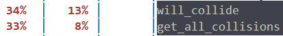

Dies lässt sich dadurch erklären, dass `np.linalg.norm` bereits für sich genommen eine relativ kostspielige Operation ist, da sie die Subtraktion zweier Vektoren, das Quadrieren ihrer Komponenten, die Summation und schließlich die Quadratwurzel umfasst – alles Schritte, die zum Rechenaufwand beitragen.

Darüber hinaus werden beide Funktionen in einer verschachtelten `for`-Schleife sehr häufig aufgerufen – im Prinzip für nahezu alle Ballpaare in jedem Zeitschritt, also etwa $≈\tfrac{N^2}{2}$ Mal (wobei $N$ die Anzahl der Bälle ist). Zusätzlich hat die Funktion `will_collide` eine eigene Schleife über das Array `k_values = [0, 0.25, 0.5, 0.75]`, was bedeutet, dass `np.linalg.norm` pro Zeitschritt vier weitere Male aufgerufen wird – also insgesamt etwa $≈4 \cdot \tfrac{N^2}{2}$ Aufrufe.

Für die Simulation mit zehn Bällen wird die Abstandsberechnung in `will_collide` jedoch nicht viel häufiger ausgeführt als in `get_all_collisions`, da `get_all_collisions` wird schon dann ausgeführt, wenn die Bälle nicht maskiert sind. Die Funktion `will_collide` hingegen wird nur dann aufgerufen, wenn die Bälle nicht maskiert sind *und* sich darüber hinaus hinreichend annähern (näher als das Vierfache der Summe ihrer Radien). Erst wenn beide Bedingungen erfüllt sind, wird `will_collide` aufgerufen. Bei nur zehn Bällen ist die Anzahl möglicher Kollisionen noch zu gering, so dass die Iteration über `k_values` noch keine dominierende Rolle hat. Daher ist der Rechenaufwand von `get_all_collisions` in diesem Fall noch vergleichbar mit dem von `will_collide`.

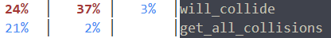

```python
c, v, m, r, mask = init(10)
```

```python
%%scalene --cpu-sampling-rate 0.01

# Funktionen will_collide und get_all_collisions werden hier nochmals aufgefuehrt, um die Scalene-Analyseergebnisse zu bekommen.

# ------------------------------
# FUNKTIONEN
# ------------------------------
def will_collide(c1, c2, v1, v2, r1, r2, dt):

    # Vorinitialisierung
    collided = False
    k_frac = 0
    c1_before = c1
    c2_before = c2
    k_values = [0, 0.25, 0.5, 0.75]  # Zeitanteile innerhalb des Zeitschritts

    for k in k_values:
        # Positionen der Bälle nach k * dt
        c1_pos = c1 + k * dt * v1
        c2_pos = c2 + k * dt * v2

        # Berechnung des Abstands nach jedem k
        distance = np.linalg.norm(c1_pos - c2_pos)

        # Wenn Abstand kleiner als die Summe der Radien beider Baelle ist, Kollision
        if distance < (r1 + r2):
            # Aktualisierung der Werte
            collided = True
            k_frac = k
            c1_before = c1_pos
            c2_before = c2_pos
            break  # Kollision gefunden, Abbruch der Schleife

    return collided, k_frac, c1_before, c2_before


def get_all_collisions(c, v, m, r, dt, mask, cooldown_frames = 7):

    N = len(c) # Anzahl der Baelle

    for i in range(N):
        for j in range(i + 1, N):

            # Prüfe, ob die Baelle maskiert sind
            if mask[i, j] > 0:
                continue  # Maske anwenden, Kollision wird nicht gecheckt

            # Prüfe, ob die Bälle nah genug sind
            distance = np.linalg.norm(c[i] - c[j])
            min_dist = r[i] + r[j]
            if distance >= 4 * min_dist:
                continue  # Baelle sind noch zu weit voneinander, Kollision wird nicht gecheckt

            # Pruefe ob die Kollision schon in diesem Zeitschritt stattfindet
            collided, k_frac, c1_before, c2_before = will_collide(c[i], c[j], v[i], v[j], r[i], r[j], dt)

            if collided:
                # Wenn Kollision, dann neue Geschwindigkeiten
                v1_new, v2_new = collision(c[i], c[j], v[i], v[j], m[i], m[j])

                # Neue Position nach der Kollision berechnen
                c[i] = c1_before + v1_new * (1 - k_frac) * dt # neue Position für Ball 1
                c[j] = c2_before + v2_new * (1 - k_frac) * dt # neue Position für Ball 2

                # Aktualisierung von v
                v[i] = v1_new
                v[j] = v2_new

                # Aktualisierung der Maske, wenn Kollisionen aufgetreten sind
                mask[i, j] = cooldown_frames
                mask[j, i] = cooldown_frames

    # Aktualisierung der Maske, wenn keine Kollisionen aufgetreten sind
    mask = np.maximum(mask - 1, 0)

    return c, v, mask

# ------------------------------
# HAUPTFUNKTION
# ------------------------------

# Initialisierung
# c, v, m, r, mask = init()

if visualize == True:
    # Fuehre Simulation mit Visualisierung durch und animiere das Ergebnis
    all_positions = [c.copy()]

    for i in range(steps):
        c, v, mask = timestep_with_collisions(c, v, m, dt, g, r, xmax, ymax, mask)
        all_positions.append(c.copy())
    print("Simulation (mit Visualisierung) war erfolgreich")
else:
    # Nur reine Simulation ohne Visualisierung
    for i in range(steps):
        timestep_with_collisions(c, v, m, dt, g, r, xmax, ymax, mask)
    print("Simulation (ohne Visualisierung) war erfolgreich")
```

```
Simulation (mit Visualisierung) war erfolgreich
     /workspaces/SC_EA1_bis_EA3/EA3/Abgabedateien/_ipython-input-21-profile: % of time = 100.00% (513.586ms) out of 513.586ms.
        ╷        ╷       ╷       ╷
        │Time    │–––––– │–––––– │
  Line  │Python  │native │system │/workspaces/SC_EA1_bis_EA3/EA3/Abgabedateien/_ipython-input-21-profile
╺━━━━━━━┿━━━━━━━━┿━━━━━━━┿━━━━━━━┿━━━━━━━━━━━━━━━━━━━━━━━━━━━━━━━━━━━━━━━━━━━━━━━━━━━━━━━━━━━━━━━━━━━━━━━━━━━━━━━━━━━━━━━━━━━━━━━━╸
      1 │        │       │       │
      2 │        │       │       │
      3 │        │       │       │# Funktionen will_collide und get_all_collisions werden hier nochmals aufgefuehrt, um die Scale
      4 │        │       │       │
      5 │        │       │       │# ------------------------------
      6 │        │       │       │# FUNKTIONEN
      7 │        │       │       │# ------------------------------
      8 │        │       │       │def will_collide(c1, c2, v1, v2, r1, r2, dt):
      9 │        │       │       │
```

[output cut: 95 more lines]

```python
c, v, m, r, mask = init(300)
```

```python
%%scalene --cpu-sampling-rate 0.01

# Funktionen will_collide und get_all_collisions werden hier nochmals aufgeführt, um die Scalene-Analyseergebnisse für ihren Code zu bekommen.

# ------------------------------
# FUNKTIONEN
# ------------------------------

def will_collide(c1, c2, v1, v2, r1, r2, dt):
    """
    Prüft, ob zwei Bälle sich innerhalb eines Zeitschritts dt kollidieren werden
    Eingabeparameter sind erweitert, um Bälle mit und Radien zu berücksichtigen.

    Parameter:
    - c1, c2:   Positionen von Ball 1 und 2
    - v1, v2:   Geschwindigkeiten von Ball 1 und 2
    - r1, r2:   Radien von Ball 1 und 2
    - dt:       Zeitschritt

    Rückgabewerte:
    - collided:                 Status: Ob eine Kollision erkannt wurde
    - k_frac:                   Fraktion des Zeitschritts, bei dem die Kollision stattfindet
    - c1_before, c2_before:     Positionen von Ball 1 und 2 vor der Kollision
    """

    # Vorinitialisierung
    collided = False
    k_frac = 0
    c1_before = c1
    c2_before = c2
    k_values = [0, 0.25, 0.5, 0.75]  # Zeitanteile innerhalb des Zeitschritts

    for k in k_values:
        # Positionen der Bälle nach k * dt
        c1_pos = c1 + k * dt * v1
        c2_pos = c2 + k * dt * v2

        # Berechnung des Abstands zwischen den Bällen nach jedem k
        distance = np.linalg.norm(c1_pos - c2_pos)

        # Wenn Abstand kleiner als die Summe der Radien beider Bälle ist -> Kollision
        if distance < (r1 + r2):
            # Aktualisierung der Werte
            collided = True
            k_frac = k
            c1_before = c1_pos
            c2_before = c2_pos
            break  # Kollision gefunden -> Abbruch der Schleife

    return collided, k_frac, c1_before, c2_before


def get_all_collisions(c, v, m, r, dt, mask, cooldown_frames = 7):
    """
    Prüft und behandelt alle möglichen Kollisionen zwischen Bällen

    Parameter:
    - c:                aktuelle Positionen von allen Bällen (Array der Form [N, 2])
    - v:                aktuelle Geschwindigkeiten von allen Bällen (Array der Form [N, 2])
    - m:                aktuelle Massen von allen Bällen (Array der Form [N, 2])
    - r:                aktuelle Radien von allen Bällen (Array der Form [N, 2])
    - dt:               Zeitschritt
    - mask:             Maske, die verhindert, dass Bälle nicht in mehreren (=cooldown_frames)
                        aufeinanderfolgenden Zeitschritten miteinander kollidieren können
    - colldown_frames:  Anzahl der Zeitschritte, bis die Bälle nach einer Kollision
                        wieder für die Berechnung der nächsten Kollision berücksichtigt werden können

    Rückgabewerte:
    - c:    Neue Positionen der Bälle nach Kollisionen
    - v:    Neue Geschwindigkeiten der Bälle nach Kollisionen
    - mask: Aktualisierte Maske
    """

    N = len(c) # Anzahl der Bälle

    for i in range(N):
        for j in range(i + 1, N):

            # Prüfe, ob die Bälle maskiert sind
            if mask[i, j] > 0:
                continue  # Maske anwenden -> Kollision wird nicht überprüft

            # Prüfe, ob die Bälle nah genug sind
            distance = np.linalg.norm(c[i] - c[j])
            min_dist = r[i] + r[j]
            if distance >= 4 * min_dist:
                continue  # Bälle sind noch zu weit voneinander -> Kollision wird nicht überprüft

            # Prüfe ob die Kollision schon in diesem Zeitschritt stattfindet
            collided, k_frac, c1_before, c2_before = will_collide(c[i], c[j], v[i], v[j], r[i], r[j], dt)

            if collided:
                # Wenn Kollision, dann neue Geschwindigkeiten
                v1_new, v2_new = collision(c[i], c[j], v[i], v[j], m[i], m[j])

                # Neue Position nach der Kollision berechnen
                c[i] = c1_before + v1_new * (1 - k_frac) * dt # neue Position für Ball 1
                c[j] = c2_before + v2_new * (1 - k_frac) * dt # neue Position für Ball 2

                # Aktualisierung von v
                v[i] = v1_new
                v[j] = v2_new

                # Aktualisierung der Maske, wenn Kollisionen aufgetreten sind
                mask[i, j] = cooldown_frames
                mask[j, i] = cooldown_frames

    # Aktualisierung der Maske, wenn keine Kollisionen aufgetreten sind
    mask = np.maximum(mask - 1, 0)

    return c, v, mask


# ------------------------------
# HAUPTFUNKTION
# ------------------------------

# Initialisierung
# c, v, m, r, mask = init()

if visualize == True:
    # Führe Simulation mit Visualisierung durch und animiere das Ergebnis
    all_positions = [c.copy()]

    for i in range(steps):
        c, v, mask = timestep_with_collisions(c, v, m, dt, g, r, xmax, ymax, mask)
        all_positions.append(c.copy())
    print("Simulation (mit Visualisierung) war erfolgreich")
else:
    # Nur reine Simulation ohne Visualisierung
    for i in range(steps):
        timestep_with_collisions(c, v, m, dt, g, r, xmax, ymax, mask)
    print("Simulation (ohne Visualisierung) war erfolgreich")
```

```
Simulation (mit Visualisierung) war erfolgreich
     /workspaces/SC_EA1_bis_EA3/EA3/Abgabedateien/_ipython-input-23-profile: % of time = 100.00% (307.943ms) out of 307.943ms.
        ╷        ╷       ╷       ╷
        │Time    │–––––– │–––––– │
  Line  │Python  │native │system │/workspaces/SC_EA1_bis_EA3/EA3/Abgabedateien/_ipython-input-23-profile
╺━━━━━━━┿━━━━━━━━┿━━━━━━━┿━━━━━━━┿━━━━━━━━━━━━━━━━━━━━━━━━━━━━━━━━━━━━━━━━━━━━━━━━━━━━━━━━━━━━━━━━━━━━━━━━━━━━━━━━━━━━━━━━━━━━━━━━╸
      1 │        │       │       │
      2 │        │       │       │
      3 │        │       │       │# Funktionen will_collide und get_all_collisions werden hier nochmals aufgeführt, um die Scalen
      4 │        │       │       │
      5 │        │       │       │# ------------------------------
      6 │        │       │       │# FUNKTIONEN
      7 │        │       │       │# ------------------------------
      8 │        │       │       │
      9 │    2%  │       │       │def will_collide(c1, c2, v1, v2, r1, r2, dt):
```

[output cut: 131 more lines]

**Aufgabe:** Versuchen Sie Ihren Code (d.h. `timestep_with_collisions`) zu optimieren, damit er besser skaliert.

Vergleichen Sie danach die Ausführungszeiten beider Varianten für 20 Zeitschritte mit $[100, 200,300]$ Bällen.

Stellen Sie den Vergleich graphisch dar.

*Points:* 10

```python
## Optimized CODE
from numba import njit, prange

# ------------------------------
# OPTIMIERUNG DER FUNKTION WILL_COLLIDE
# ------------------------------

@njit
def will_collide_numba(c1, c2, v1, v2, r1, r2, dt):

    collided = False
    k_frac = 0
    c1_before = c1
    c2_before = c2
    k_values = [0, 0.25, 0.5, 0.75]

    for k in k_values:
        c1_pos = c1 + k * dt * v1
        c2_pos = c2 + k * dt * v2

        distance = np.linalg.norm(c1_pos - c2_pos)

        if distance < (r1 + r2):
            collided = True
            k_frac = k
            c1_before = c1_pos
            c2_before = c2_pos
            break

    return collided, k_frac, c1_before, c2_before

# ------------------------------
# OPTIMIERUNG DER FUNKTION COLLISION
# ------------------------------

@njit
def collision_numba(c1, c2, v1, v2, m1, m2):

    r = c1 - c2
    factor = np.dot((v1 - v2), r) / np.linalg.norm(r)**2 * r
    v1_new = v1 - 2 * m2 / (m1 + m2) * factor
    v2_new = v2 + 2 * m1 / (m1 + m2) * factor

    return v1_new, v2_new

# ------------------------------
# OPTIMIERUNG FUNKTION GET_ALL_COLLISIONS
# ------------------------------

@njit
def get_all_collisions_numba(c, v, m, r, dt, mask, cooldown_frames = 7):

    N = len(c)

    for i in prange(N): # parallele Ausführung der for-Schleife
        for j in range(i + 1, N):
            if mask[i, j] > 0:
                continue

            distance = np.linalg.norm(c[i] - c[j])
            min_dist = r[i] + r[j]
            if distance >= 4 * min_dist:
                continue

            collided, k_frac, c1_before, c2_before = will_collide_numba(c[i], c[j], v[i], v[j], r[i], r[j], dt)

            if collided:
                v1_new, v2_new = collision_numba(c[i], c[j], v[i], v[j], m[i], m[j])

                c[i] = c1_before + v1_new * (1 - k_frac) * dt
                c[j] = c2_before + v2_new * (1 - k_frac) * dt

                v[i] = v1_new
                v[j] = v2_new

                mask[i, j] = cooldown_frames
                mask[j, i] = cooldown_frames

    mask = np.maximum(mask - 1, 0)

    return c, v, mask

# ------------------------------
# OPTIMIERUNG DER FUNKTION TIMESTEP_WITH_COLLISIONS
# ------------------------------

@njit
def timestep_with_collisions_numba(c, v, m, dt, g, r, xmax, ymax, mask):

    v_new = v + dt * g
    c_new = c + dt * v_new

    c_new, v_new, mask = get_all_collisions_numba(c_new, v_new, m, r, dt, mask)


    # Kollisionen mit linken/rechten Wänden
    left_wall = c_new[:, 0] <= 0
    right_wall = c_new[:, 0] >= xmax

    dt2_left_wall = np.abs(c_new[left_wall, 0]) / np.abs(v[left_wall, 0]) # np.abs statt abs für Numba-Optimierung
    dt2_right_wall = (np.abs(c_new[right_wall,0]) - xmax) / np.abs(v[right_wall, 0]) # np.abs statt abs für Numba-Optimierung
    v_new[left_wall | right_wall, 0] *= -1
    c_new[left_wall, 0] = dt2_left_wall * v_new[left_wall, 0]
    c_new[right_wall, 0] = xmax - dt2_right_wall * v_new[right_wall, 0]

    # Kollisionen mit oberen/unteren Wänden
    k = 1e-8

    bottom = c_new[:, 1] <= 0
    top = c_new[:, 1] >= ymax

    dt2_bottom = np.abs(c_new[bottom, 1]) / np.abs(v[bottom, 1] + k) # np.abs statt abs für Numba-Optimierung
    dt2_top = (np.abs(c_new[top, 1]) - ymax) / np.abs(v[top, 1] + k) # np.abs statt abs für Numba-Optimierung

    dt1_bottom = dt - dt2_bottom
    dt1_top = dt - dt2_top

    v_before_bottom = v[bottom, 1] + dt1_bottom * g[1]
    v_before_top = v[top, 1] + dt1_top * g[1]

    v_new[bottom, 1] = (-1) * v_before_bottom + dt2_bottom * g[1]
    v_new[top, 1] = (-1) * v_before_top + dt2_top * g[1]

    c_new[bottom, 1] = dt2_bottom * v_new[bottom, 1]
    c_new[top, 1] = ymax - dt2_top * v_new[top, 1]

    # Stabilisierung am Boden
    small_jump = (v_new[:, 1] < 0.001) & bottom
    v_new[small_jump, 1] = 0.0
    c_new[small_jump, 1] = 0.0

    return c_new, v_new, mask
```

```python
# ------------------------------
# ANFANGSBEDINGUNGEN
# ------------------------------
g = np.array([0, -9.81], dtype=np.float64)
xmax = 100
ymax = 100
steps = 20
# dt = xmax * 1e-5
dt = 0.1

# Anzahl Bälle
N = 10

rng = np.random.default_rng(seed=123)

# Flag zur Aktivierung der Visualisierung (Trennung der Simulation und Visualisierung)
visualize = False

# Startpositionen
def init(n=N):
    c = xmax * rng.random((N, 2))
    # Startgeschwindigkeiten, max.
    v = np.array([xmax/10, ymax/10]) * rng.random((N, 2))
    # Masse
    m = rng.uniform(5, 15, size=N)
    r = np.sqrt(m)
    mask = np.full((N, N), 0, np.int32)
    return c, v, m, r, mask


# ------------------------------
# HAUPTFUNKTION
# ------------------------------
c, v, m, r, mask = init()

if visualize == True:
    # Führe Simulation mit Visualisierung durch und animiere das Ergebnis
    all_positions = [c.copy()]

    for i in range(steps):
        c, v, mask = timestep_with_collisions_numba(c, v, m, dt, g, r, xmax, ymax, mask)
        all_positions.append(c.copy())

    print("Numba-optimierte Simulation (mit Visualisierung) war erfolgreich")
else:
    # Nur reine Simulation ohne Visualisierung
    for i in range(steps):
        timestep_with_collisions_numba(c, v, m, dt, g, r, xmax, ymax, mask)
    print("Numba-optimierte Simulation (ohne Visualisierung) war erfolgreich")
```

```
Numba-optimierte Simulation (ohne Visualisierung) war erfolgreich
```

```
Numba  (100 balls): 0.012 s
Python (100 balls): 0.435 s
Numba  (200 balls): 0.047 s
Python (200 balls): 1.687 s
Numba  (300 balls): 0.107 s
Python (300 balls): 3.836 s
```

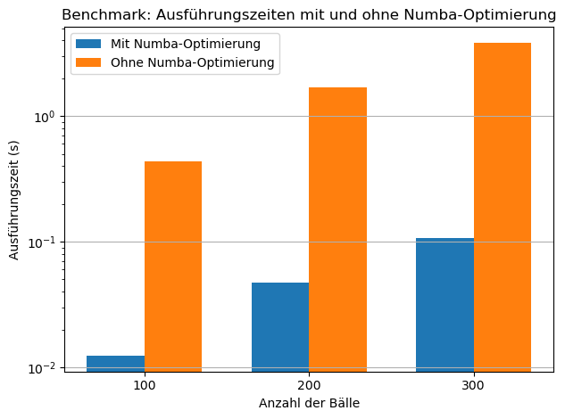

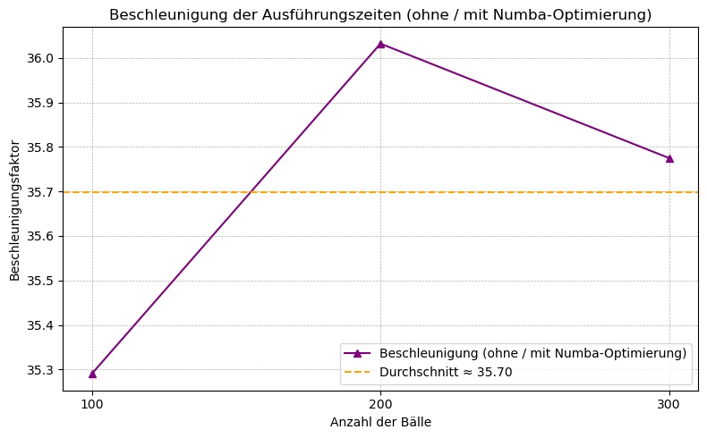

```python
# Benchmark der Ausführungszeiten mit und ohne Numba-Optimierung
# Graphische Darstellung der Ergebnisse

# ------------------------------
# INITIALISIERUNG UND BENCHMARK FUNKTIONEN
# ------------------------------

# Startpositionen
def init(N, xmax, ymax, rng):
    c = xmax * rng.random((N, 2))
    v = np.array([xmax/10, ymax/10]) * rng.random((N, 2))
    m = rng.uniform(5, 15, size=N)
    r = np.sqrt(m)
    mask = np.full((N, N), 0, np.int32)
    return c, v, m, r, mask


def benchmark(num_balls_list):
    """
    Vergleicht die Ausführungszeiten der Simulation mit und ohne Numba-Optimierung

    Paramter:
    - num_balls_list:   Liste mit der Anzahl der Bälle für die Simulation

    Rückgabewerte:
    - times_numba:      Ausführungszeiten mit Numba-Optimierung
    - times_python:     Ausführungszeiten ohne Numba-Optimierung
    """
    # Listen zur Speicherung der Ausführungszeiten für Numba- und Python-Versionen
    times_numba = []
    times_python = []

    # Allgemeine Simulationsparameter
    g = np.array([0, -9.81], dtype=np.float64)
    xmax = 100
    ymax = 100
    steps = 20
    dt = 0.1
    rng = np.random.default_rng(seed=123)

    # Iteration über die Liste mit der Anzahl der Bälle
    for i, N in enumerate(num_balls_list):
        # Initialisiere Positionen, Geschwindigkeiten, Massen, Radien und Kollisionsmaske
        c, v, m, r, mask = init(N, xmax, ymax, rng)

        # Definition einer Hilfsfunktion, die die Numba-Version für N Schritte ausführt
        def run_numba():
            c_numba, v_numba, mask_numba = c.copy(), v.copy(), mask.copy() # Kopien für unabhängige Ausführung
            for _ in range(steps):
                c_numba, v_numba, mask_numba = timestep_with_collisions_numba(c_numba, v_numba, m, dt, g, r, xmax, ymax, mask_numba)

        # Definition einer Hilfsfunktion, die die Python-Version für N Schritte ausführt
        def run_python():
            c_py, v_py, mask_py = c.copy(), v.copy(), mask.copy() # Kopien für unabhängige Ausführung
            for _ in range(steps):
                c_py, v_py, mask_py = timestep_with_collisions(c_py, v_py, m, dt, g, r, xmax, ymax, mask_py)

        # Zeitmessung der Numba- und Python-Versionen mit timeit
        repeat = 10
        t_numba = timeit(run_numba, number=repeat) / repeat
        repeat = 2
        t_python = timeit(run_python, number=repeat) / repeat

        # Speichere gemessene Zeiten
        times_numba.append(t_numba)
        times_python.append(t_python)

        # Ausgabe der Laufzeiten
        if i > 0: # Überspringen die Laufzeiten für Warm-up
            print(f"Numba  ({N} balls): {t_numba:.3f} s")
            print(f"Python ({N} balls): {t_python:.3f} s")

    return times_numba, times_python

# ------------------------------
# HAUPTFUNKTION
# ------------------------------

# Benchmark-Liste mit der Anzahl der Bälle
original_list = [100, 200, 300]
# Der erste Wert doppelt (für Numba-Warmup)
num_balls_list = [original_list[0]] + original_list  # -> [100, 100, 200, 300]

# Starte Benchmark
times_numba, times_python = benchmark(num_balls_list)


# ------------------------------
# VISUALISIERUNG DER LAUFZEITEN
# ------------------------------
# Balkendiagramm - Vergleich der Ausführungszeiten
x = np.arange(len(original_list))
width = 0.35

fig, ax = plt.subplots()
bars1 = ax.bar(x - width/2, times_numba[1:], width, label='Mit Numba-Optimierung') # Ohne den ersten Warmup-Wert
bars2 = ax.bar(x + width/2, times_python[1:], width, label='Ohne Numba-Optimierung')

ax.set_xlabel("Anzahl der Bälle")
ax.set_ylabel("Ausführungszeit (s)")
ax.set_title("Benchmark: Ausführungszeiten mit und ohne Numba-Optimierung")
ax.set_xticks(x)
ax.set_xticklabels(original_list)
ax.set_yscale('log')
ax.legend()
ax.grid(True, axis='y')

plt.tight_layout()
plt.show()


# Liniendiagramm - Beschleunigung der Ausführungszeit
speedup = np.array(times_python[1:]) / np.array(times_numba[1:])
avg_speedup = np.mean(speedup) # Durchschnittlicher Wert

plt.figure(figsize=(8, 5))
plt.plot(original_list, speedup, marker='^', color='purple', label='Beschleunigung (ohne / mit Numba-Optimierung)')
plt.axhline(avg_speedup, color='orange', linestyle='--', label=f'Durchschnitt ≈ {avg_speedup:.2f}')
plt.xlabel("Anzahl der Bälle")
plt.ylabel("Beschleunigungsfaktor")
plt.title("Beschleunigung der Ausführungszeiten (ohne / mit Numba-Optimierung)")
plt.xticks(original_list)
plt.grid(True, linestyle='--', linewidth=0.5)
plt.legend()
plt.tight_layout()
plt.show()
```

## Optimierung des Gauß-Verfahrens (30 Punkte)

**Aufgabe:** Optimieren Sie die Funktionen `lu_decomposition` und `custom_solve` aus der zweiten Einsendeaufgabe mit Hilfe von Numba.

An welcher Stelle ist die Verwendung von `prange` richtig und sinnvoll?

Vergleichen Sie die Performance vor und nach der Optimierung für Gleichungssysteme der Größe $256\times 256 $ und $512 \times 512$.

Stellen Sie den Vergleich graphisch dar.

*Points:* 30

## Python Funktionen vorbereiten

Es wird die aus EA1 bekannte Funktion **`b_solve`** definiert, die ein lineares Gleichungssystem (Ax = b) für eine obere Dreiecksmatrix (A) mittels Rückwärtssubstitution löst.

Die Funktion wurde leicht abgewandelt indem sie nun nicht mehr numpys `np.dot` verwendet, mit welchem zuvor eine innere Schleife vermieden wurde. Die inner Schleife wird hier gezielt wieder eingeführt um eine Parallelisierung mittels numbas `prange` zu ermöglichen. In den Funktionen **`l_solve`** und **`lu_decomposition`** wurde durch äquivalentes Vorgehen ebenfalls eine Parallelisierung der inneren Schleife ermöglicht. Es wird sich zeigen, dass `prange` nur sinnvoll in **`lu_decomposition`** ist.

Wichtig ist, dass die äußere Schleife nie parallel bearbeitet werden sollte, da in dieser Matrixoperationen Ergebnisse aus vorangegangenen Operationen als Parameter verwenden. Solch eine Parallelisierung ist tatsächlich im Code implementierbar, was dann aber zu undefiniertem Verhalten und falschen Ergebnissen führt.

```python
def b_solve(A, b):
    """Löst ein lineares Gleichungssystem Ax = b wobei A eine obere Dreiecksmatrix ist"""

    x = np.zeros_like(b, dtype=np.float64)  # Vektor für die Lösung, initialisiert mit Nullen
    n = b.shape[0]

    # Rückwärtssubstitution
    for i in range(n - 1, -1, -1):
        #langsamer summation = np.dot(A[i, i + 1:], x[i + 1:]) # hier wird die Vektorisierung, die numpy zur Verfügung stellt, benutzt, um die Effizienz zu erhöhen
        #langsamer x[i] = (b[i] - summation) / A[i, i]  # Berechnung des aktuellen x[i]

        # Berechnung der Summe der Produkte der bekannten x-Werte
        summation = b[i]
        for j in prange(i+1, n): # prange für parallel
            summation -= A[i, j] * x[j]
        x[i] = summation / A[i, i]
    return x

def lu_decomposition(A):
    """L und U Matrix werden innerhalb von A Matrix berechnet und der Pivot-Vektor wird ausgegeben"""

    n = A.shape[0]
    P = np.arange(n)
    for k in range(n):

        # Pivotisierung: Index der Zeile mit größtem Betrag in Spalte k finden
        pivot_index = np.argmax(np.abs(A[k:n, k])) + k
        if A[pivot_index, k] == 0:
            raise ValueError("Matrix ist singulär.")

        # Zeilen tauschen in A
        if pivot_index != k:
            A[np.array([k, pivot_index]), :] = A[np.array([pivot_index, k]), :]
            P[np.array([k, pivot_index])] = P[np.array([pivot_index, k])]

        #langsamer A[k+1:n, k] /= A[k, k]    # Berechnung L unterhalb der Diagonale
        #langsamer A[k+1:n, k+1:n] -= np.outer(A[k+1:n, k], A[k, k+1:n])    # Berechnung U obere Dreiecksmatrix inklusive Diagonale

        # Multiplikatoren berechnen
        v = A[k+1:n, k] / A[k, k]
        A[k+1:n, k] = v
        # Elimination im Rest der Matrix parallelisiert
        for i in prange(k+1, n):
            A[i, k+1:n] -= v[i - (k+1)] * A[k, k+1:n]

    return P #Pivot-Vektor

def l_solve(A, y):
    """Lösen von Ly = b[P] mit Vorwärtssubstitution. L ist untere Dreiecksmatrix mit Einheitsdiagonale"""

    # b[P] wird direkt als Parameter y übergeben und inplace berechnet
    n = y.shape[0]
    # Vorwärtssubstitution
    for i in range(n):
        # langsamer y[i] -= np.dot(A[i,:i], y[:i])
        summation = y[i]
        for j in prange(i):
            summation -= A[i, j] * y[j]
        y[i] = summation
    return y

def custom_solve(A, b):
    """Löst ein lineares Gleichungssystem Ax = b mittels LU-Zerlegung und gib Vektor x aus"""

    A = A.astype(np.float64)    # Sicherstellen, dass mit floats gerechnet wird
    b = b.astype(np.float64)

    P = lu_decomposition(A)    # Pivot-Vektor und A (welches LU-Zerlegung enthält) werden berechnet
    y = l_solve(A, b[P])    # Ly = b[P] wird gelöst für y
    x = b_solve(A, y)    # Ux = y wird gelöst für x
    return x
```

## JIT‑Kompilierung und Parallelvarianten

In der nächsten Zelle werden alle zuvor definierten Python‑Funktionen mittels Numba JIT kompiliert, sodass sie in nativem Maschinencode ausgeführt werden können:

- **Serielle JIT‑Versionen**  
  `b_solve_njit`, `lu_decomposition_njit` und `l_solve_njit` werden mit `njit` kompiliert.
- **Parallelisierte JIT‑Versionen**  
  `b_solve_njit_par`, `lu_decomposition_njit_par` und `l_solve_njit_par` nutzen `parallel=True` für Multi‑Core‑Execution.
- **Gesamtfunktionen**
- `cs_njit`: Führt LU‑Zerlegung, Vorwärts‑ und Rückwärtssubstitution vollständig in reinem Numba‑Code aus dank jit-Kompilierung.
- `cs_parallel_solve`: Verwendet zusätzlich zu njit parallele Vorwärts- und Rückwärtssubstitution aber serielle LU-Zerlegung
- `cs_parallel_lu`: Verwendet zusätzlich zu njit parallele Ausführung der LU‑Zerlegung gefolgt von serieller Substitution.

```python
#njit Versionen aller python Funktionen
#njit steht für "No python objects Just In Time compilation"
b_solve_njit = njit(b_solve)
lu_decomposition_njit = njit(lu_decomposition)
l_solve_njit = njit(l_solve)

#njit Versionen parallelisiert
b_solve_njit_par = njit(b_solve, parallel=True)
lu_decomposition_njit_par = njit(lu_decomposition, parallel=True)
l_solve_njit_par = njit(l_solve, parallel=True)


@njit
def cs_njit(A, b):
    """njit Version von custom_solve"""
    A = A.astype(np.float64)    # Sicherstellen, dass mit floats gerechnet wird
    b = b.astype(np.float64)

    P = lu_decomposition_njit(A)    # Pivot-Vektor und A (welches LU-Zerlegung enthält) werden berechnet
    y = l_solve_njit(A, b[P])    # Ly = b[P] wird gelöst für y
    x = b_solve_njit(A, y)    # Ux = y wird gelöst für x
    return x

@njit
def cs_parallel_solve(A, b):
    """njit Version von custom_solve mit solve Funktionen parallel"""
    A = A.astype(np.float64)    # Sicherstellen, dass mit floats gerechnet wird
    b = b.astype(np.float64)

    P = lu_decomposition_njit(A)    # Pivot-Vektor und A (welches LU-Zerlegung enthält) werden berechnet
    y = l_solve_njit_par(A, b[P])    # Ly = b[P] wird gelöst für y
    x = b_solve_njit_par(A, y)    # Ux = y wird gelöst für x
    return x

@njit
def cs_parallel_lu(A, b):
    """njit Version von custom_solve mit lu_decomposition parallel"""
    A = A.astype(np.float64)    # Sicherstellen, dass mit floats gerechnet wird
    b = b.astype(np.float64)

    P = lu_decomposition_njit_par(A)    # Pivot-Vektor und A (welches LU-Zerlegung enthält) werden berechnet
    y = l_solve_njit(A, b[P])    # Ly = b[P] wird gelöst für y
    x = b_solve_njit(A, y)    # Ux = y wird gelöst für x
    return x
```

## Messung der Laufzeiten

Es erfolgt ein systematischer Test der verschiedenen Lösungsvarianten:

- **Konfiguration**  
  Festlegung von `iterations` (Anzahl der Durchläufe), `dimensions` (Matrixgrößen) und  
  `function_variations` (Liste der Solve‑Funktionen: `cs_njit`, `cs_parallel_solve`, `cs_parallel_lu`, `custom_solve`).
- **Initialisierung der Laufzeitspeicher**  
  Ein Dictionary `run_times_dict` wird angelegt, um für jede Methode und Matrixdimension die kumulierten Laufzeiten zu erfassen.
- **Testschleifen**  
  Für jede Matrixgröße und jede Funktion wird eine belibiebige Matrix A erzeugt, die Lösung entsprechend der Methode berechnet, mit `linalg.solve` auf  
  Korrektheit geprüft (mittels `assert`) und die benötigte Zeit gemessen.
- **Ergebnisaggregation**  
  Die gemessenen Laufzeiten aller Iterationen werden summiert und in `run_times_dict` abgelegt, um später eine Performance‑Analyse durchzuführen.
- **Resultat**  
  Numba verbessert die Laufzeit deutlich. Die Verwendung von `prange` lohnt sich nur für die innere Schleife der LU‑Zerlegung bei großen Matrizen wie es in der Funktion `cs_parallel_lu` angewendet wird.  
  Die Laufzeiten variieren wieder von System zu System.

```python
# Vergleicht Ergebnisse von custom_solve mit linalg.solve mittels assert-Bedingung
# berechnet auch die Laufzeit

iterations = 50    # Anzahl der Wiederholungen
dimensions = [256, 512]    # Matrix A hat Dimension n x n
function_variations = [cs_njit, cs_parallel_solve, cs_parallel_lu, custom_solve] # Funktionsvarianten von custom_solve
run_times_dict = dict([(f.__name__, dict([(n,0.) for n in dimensions])) for f in function_variations])    # dict in dem die run_times gemessen werden

print(f"{'Funktionsvariante':<18} {'Dimension':<10} {'Ø-Laufzeit':<12}")
# unterschiedliche Funktions varianten werden variiert
for custom_solve_variation in function_variations:
    if custom_solve_variation == custom_solve:
        iterations = max(1, iterations//5)

    _run_times = run_times_dict[custom_solve_variation.__name__] # run_times der aktuellen Funktion

    for n in dimensions:
        rng = np.random.default_rng(seed=123)    # random seed für Reproduzierbarkeit
        A = rng.random((n, n))
        b = rng.random(n)
        linalg_x = linalg.solve(A, b)    # Ergebniss von linalg.solve zum Prüfen der Korrektheit

        for run in range(iterations + 1):     # Funktionen wiederholen zum testen der Performance
            start_ns = perf_counter_ns()     # Startzeitpunkt in ns
            custom_x = custom_solve_variation(A, b)
            if run > 0: # Durchlauf 0 compiliert und weicht von der Laufzeit stark ab
                _run_times[n] += perf_counter_ns() - start_ns # Laufzeit in ns wird in dict summiert

        # durchschnittliche Laufzeit in ms
        _run_times[n] /= (iterations * 1e6)

        #sicherstellen, dass Ergebnisse gleich sind, float-Unpräzision ignorieren
        assert np.allclose(linalg_x, custom_x), f"Fehler bei Dimension {n} mit Funktion {custom_solve_variation.__name__}"

        print(f"{custom_solve_variation.__name__:<18} {n:<10} {_run_times[n]:.3f} ms")
    print()    # Leerzeile
```

```
Funktionsvariante  Dimension  Ø-Laufzeit
cs_njit            256        3.199 ms
cs_njit            512        22.993 ms

cs_parallel_solve  256        6.943 ms
cs_parallel_solve  512        32.084 ms

cs_parallel_lu     256        7.136 ms
cs_parallel_lu     512        14.880 ms

custom_solve       256        52.907 ms
custom_solve       512        219.524 ms
```

```python
%%timeit
custom_x = cs_njit(A, b)    # berechnete Laufzeit kann mit %%timeit line-magic verifiziert werden
```

```
23.6 ms ± 16.2 µs per loop (mean ± std. dev. of 7 runs, 10 loops each)
```

## Visualisierung der Laufzeiten

In der nächsten Zelle werden die durchschnittlichen Laufzeiten aller Solve‑Varianten je Matrixdimension berechnet und als logarithmisches Balkendiagramm dargestellt:

- **Berechnung der Durchschnittswerte**  
  Die in `run_times_dict` gesammelten Gesamtlaufzeiten wurden durch `iterations` geteilt und von Nanosekunden in Millisekunden umgerechnet.
- **Erstellung des Balkendiagramms**  
  Für jede Funktion werden nebeneinanderstehende Balken gezeichnet. Die Variable `width` steuert die Breite, und die x‑Positionen werden entsprechend der Anzahl der Funktionen verschoben.
- **Logarithmische Skalierung**  
  Die y‑Achse ist mit `plt.yscale('log')` auf Log‑Skala eingestellt, um große Zeitunterschiede übersichtlich abzubilden.
- **Anpassung der Achsenbeschriftungen**
  - x‑Ticks entsprechen den Matrixdimensionen (`dimensions`)
  - y‑Ticks werden auf die Original‑Werte gesetzt und mit einer Nachkommastelle formatiert
- **Feinschliff**  
  Achsentitel, Diagrammtitel, Legende und Gitternetzlinien werden hinzugefügt; abschließend sorgt `plt.tight_layout()` für ein sauberes Layout.

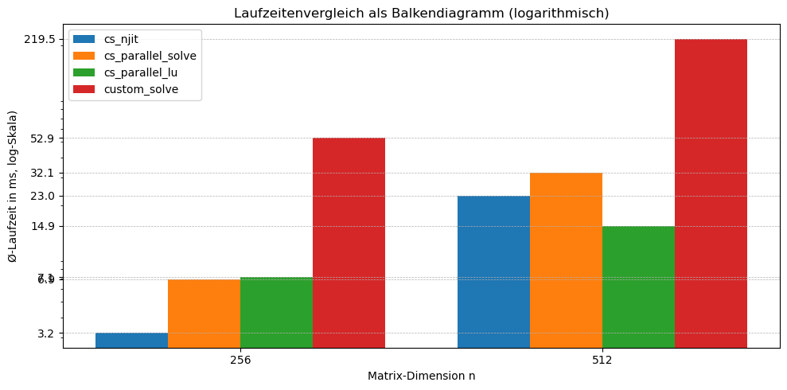

```python
# Berechnung der Durchschnittlichen Laufzeiten in ms pro Dimension
run_times_means = dict([(func, [v for v in run_times_dict[func].values()]) for func in run_times_dict])

# Plot-Einstellungen
#x = list(range(len(dimensions))  # Positionen für Dimensionsgruppen
width = .2                # Breite der Balken

plt.figure(figsize=(10, 5))
for i, func in enumerate(run_times_means.keys()):
    plt.bar([x + i * width for x in range(len(dimensions))], run_times_means[func], width, label=func)

plt.xlabel('Matrix-Dimension n')
plt.ylabel('Ø-Laufzeit in ms, log-Skala)')
plt.title('Laufzeitenvergleich als Balkendiagramm (logarithmisch)')
plt.yscale('log')

# Alle Werte sammeln und sortieren für die Achsenbeschriftung
all_times = [t for _run_times in run_times_means.values() for t in _run_times]
# Setze y-Ticks auf die Originalwerte
plt.yticks(all_times, [f"{t:.1f}" for t in all_times])

# Position von n auf der x-Achse
plt.xticks([x + width * (len(run_times_means) - 1) / 2 for x in range(len(dimensions))], dimensions)
plt.legend()
plt.grid(axis='y', which='major', linestyle='--', linewidth=0.5)
plt.tight_layout()
plt.show()
```

## Schnittpunkt‑Analyse und Liniendiagramm

In der nächsten Zelle werden die logarithmisch interpolierten Laufzeiten für `cs_njit` und `cs_parallel_lu` bestimmt und ihr Schnittpunkt im Liniendiagramm visualisiert.  
Es wird davon ausgegangen, dass die Laufzeiten von Komplexität O(n²) sind und mit der Anzahl der Matrixeinträge steigen.

```
Ab einer Matrix mit Dimension 422 sollte cs_parallel_lu am schnellsten sein mit einer Laufzeit von 11.48ms.
```

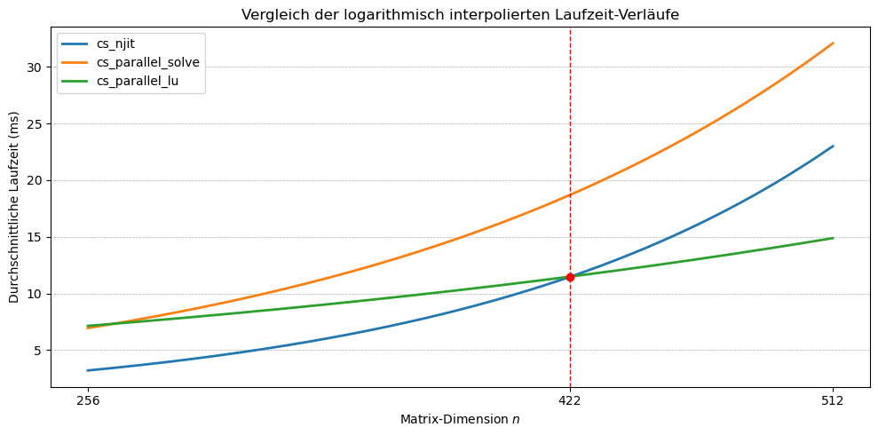

```python
# Schnittpunkt berechnen von der Laufzeit von cs_njit cs_parallel_lu

# Log-Interpolation
# Log-Verläufe werden berechnet
n1, n2 = 256, 512

y1_njit, y2_njit = np.log2(run_times_means['cs_njit'])
log_space_njit = np.logspace(y1_njit, y2_njit, n1, base=2)

y1_lu, y2_lu = np.log2(run_times_means['cs_parallel_lu'])
log_space_lu = np.logspace(y1_lu, y2_lu, n1, base=2)

y1_ps, y2_ps = np.log2(run_times_means['cs_parallel_solve'])
log_space_ps = np.logspace(y1_ps, y2_ps, n1, base=2)

n_values = np.linspace(n1, n2, n2-n1)


#  Schnittpunktindex der beiden Kurven im Log-Bereich
idx    = np.argmin(np.abs(log_space_lu - log_space_njit))
n_int  = n_values[idx]
y_int  = log_space_lu[idx]

print(f"Ab einer Matrix mit Dimension {n_int:.0f} sollte cs_parallel_lu am schnellsten sein mit einer Laufzeit von {y_int:.2f}ms.")

# Plot
plt.figure(figsize=(10, 5))
plt.plot(n_values, log_space_njit, label='cs_njit',           linewidth=2)
plt.plot(n_values, log_space_ps,    label='cs_parallel_solve',  linewidth=2)
plt.plot(n_values, log_space_lu,    label='cs_parallel_lu',  linewidth=2)


# Schnittpunkt markieren mit vertikaler Linie
plt.scatter([n_int], [y_int],       color='red', zorder=5)
plt.axvline(n_int, linestyle='--', color='red', linewidth=1)

plt.xlabel('Matrix-Dimension $n$')
plt.ylabel('Durchschnittliche Laufzeit (ms)')
plt.title('Vergleich der logarithmisch interpolierten Laufzeit-Verläufe')
plt.xticks([n1, n_int, n2], [str(n1), f'{n_int:.0f}', str(n2)])
plt.legend()
plt.grid(axis='y', which='major', linestyle='--', linewidth=0.5)
plt.tight_layout()
plt.show()
```

```python
# Überprüfung der Performance im berechneten Schnittpunkt

n = round(n_int)
rng = np.random.default_rng(seed=123)    # random seed für Reproduzierbarkeit
A = rng.random((n, n))
b = rng.random(n)

print(f"Tatsächliche Laufzeiten bei Dimension {n}:")
print("cs_njit:       ", end=" ")
%timeit cs_njit(A, b)

print("cs_parallel_lu:", end=" ")
%timeit cs_parallel_lu(A, b)
```

```
Tatsächliche Laufzeiten bei Dimension 422:
cs_njit:        12.6 ms ± 16.7 µs per loop (mean ± std. dev. of 7 runs, 100 loops each)
cs_parallel_lu: 11.2 ms ± 1.48 ms per loop (mean ± std. dev. of 7 runs, 100 loops each)
```

Führen Sie alle Zellen im Notebook aus und speichern Sie es.  
Danach können Sie mit der folgenden Zelle eine HTML-Datei erstellen.  
Eine mögliche `UserWarning` können Sie ignorieren.  
Bitte geben Sie das Notebook als `.ipynb` und `.html` Datei ab.

```python
#!jupyter nbconvert --to html EA3.ipynb
```